```python
import numpy as np
import pandas as pd

import seaborn as sns
import matplotlib.pyplot as plt

from scipy.stats import chi2_contingency, norm, zscore
from scipy.stats import skew, kurtosis
from scipy.stats import ttest_ind, mannwhitneyu, shapiro

import statsmodels.api as sm
```

# 1. Load and Preprocess the Data

```python
control_df = pd.read_csv('control_group.csv')
test_df = pd.read_csv('test_group.csv')
```

```python
control_df.head()
```

|  | Campaign Name;Date;Spend [USD];# of Impressions;Reach;# of Website Clicks;# of Searches;# of View Content;# of Add to Cart;# of Purchase |
| --- | --- |
| 0 | Control Campaign;1.08.2019;2280;82702;56930;70... |
| 1 | Control Campaign;2.08.2019;1757;121040;102513;... |
| 2 | Control Campaign;3.08.2019;2343;131711;110862;... |
| 3 | Control Campaign;4.08.2019;1940;72878;61235;30... |
| 4 | Control Campaign;5.08.2019;1835;;;;;;; |

```python
control_df = pd.read_csv('control_group.csv', sep =";")
test_df = pd.read_csv('test_group.csv', sep =";")
```

```python
control_df.head()
```

|  | Campaign Name | Date | Spend [USD] | # of Impressions | Reach | # of Website Clicks | # of Searches | # of View Content | # of Add to Cart | # of Purchase |
| --- | --- | --- | --- | --- | --- | --- | --- | --- | --- | --- |
| 0 | Control Campaign | 1.08.2019 | 2280 | 82702.0 | 56930.0 | 7016.0 | 2290.0 | 2159.0 | 1819.0 | 618.0 |
| 1 | Control Campaign | 2.08.2019 | 1757 | 121040.0 | 102513.0 | 8110.0 | 2033.0 | 1841.0 | 1219.0 | 511.0 |
| 2 | Control Campaign | 3.08.2019 | 2343 | 131711.0 | 110862.0 | 6508.0 | 1737.0 | 1549.0 | 1134.0 | 372.0 |
| 3 | Control Campaign | 4.08.2019 | 1940 | 72878.0 | 61235.0 | 3065.0 | 1042.0 | 982.0 | 1183.0 | 340.0 |
| 4 | Control Campaign | 5.08.2019 | 1835 | NaN | NaN | NaN | NaN | NaN | NaN | NaN |

```python
control_df.info()
```

```
<class 'pandas.core.frame.DataFrame'>
RangeIndex: 30 entries, 0 to 29
Data columns (total 10 columns):
 #   Column               Non-Null Count  Dtype
---  ------               --------------  -----
 0   Campaign Name        30 non-null     object
 1   Date                 30 non-null     object
 2   Spend [USD]          30 non-null     int64
 3   # of Impressions     29 non-null     float64
 4   Reach                29 non-null     float64
 5   # of Website Clicks  29 non-null     float64
 6   # of Searches        29 non-null     float64
 7   # of View Content    29 non-null     float64
 8   # of Add to Cart     29 non-null     float64
 9   # of Purchase        29 non-null     float64
dtypes: float64(7), int64(1), object(2)
memory usage: 2.5+ KB
```

```python
test_df.head()
```

|  | Campaign Name | Date | Spend [USD] | # of Impressions | Reach | # of Website Clicks | # of Searches | # of View Content | # of Add to Cart | # of Purchase |
| --- | --- | --- | --- | --- | --- | --- | --- | --- | --- | --- |
| 0 | Test Campaign | 1.08.2019 | 3008 | 39550 | 35820 | 3038 | 1946 | 1069 | 894 | 255 |
| 1 | Test Campaign | 2.08.2019 | 2542 | 100719 | 91236 | 4657 | 2359 | 1548 | 879 | 677 |
| 2 | Test Campaign | 3.08.2019 | 2365 | 70263 | 45198 | 7885 | 2572 | 2367 | 1268 | 578 |
| 3 | Test Campaign | 4.08.2019 | 2710 | 78451 | 25937 | 4216 | 2216 | 1437 | 566 | 340 |
| 4 | Test Campaign | 5.08.2019 | 2297 | 114295 | 95138 | 5863 | 2106 | 858 | 956 | 768 |

```python
test_df.info()
```

```
<class 'pandas.core.frame.DataFrame'>
RangeIndex: 30 entries, 0 to 29
Data columns (total 10 columns):
 #   Column               Non-Null Count  Dtype
---  ------               --------------  -----
 0   Campaign Name        30 non-null     object
 1   Date                 30 non-null     object
 2   Spend [USD]          30 non-null     int64
 3   # of Impressions     30 non-null     int64
 4   Reach                30 non-null     int64
 5   # of Website Clicks  30 non-null     int64
 6   # of Searches        30 non-null     int64
 7   # of View Content    30 non-null     int64
 8   # of Add to Cart     30 non-null     int64
 9   # of Purchase        30 non-null     int64
dtypes: int64(8), object(2)
memory usage: 2.5+ KB
```

```python
# Drop not needed columns
control_df.drop(columns=['Campaign Name'], inplace=True)
test_df.drop(columns=['Campaign Name'], inplace=True)
```

```python
column_names = ['Date', 'Spent', 'Impressions',
                'Reach', 'Clicks', 'Searches',
                'Views', 'Add to Cart', 'Purchases']
control_df.columns = column_names
test_df.columns = column_names
```

```python
control_df.info()
```

```
<class 'pandas.core.frame.DataFrame'>
RangeIndex: 30 entries, 0 to 29
Data columns (total 9 columns):
 #   Column       Non-Null Count  Dtype
---  ------       --------------  -----
 0   Date         30 non-null     object
 1   Spent        30 non-null     int64
 2   Impressions  29 non-null     float64
 3   Reach        29 non-null     float64
 4   Clicks       29 non-null     float64
 5   Searches     29 non-null     float64
 6   Views        29 non-null     float64
 7   Add to Cart  29 non-null     float64
 8   Purchases    29 non-null     float64
dtypes: float64(7), int64(1), object(1)
memory usage: 2.2+ KB
```

```python
# Impute the missing values in columns 2-8
control_df.iloc[:, 2:] = control_df.iloc[:, 2:].fillna(control_df.iloc[:, 2:].median())

control_df.info()
```

```
<class 'pandas.core.frame.DataFrame'>
RangeIndex: 30 entries, 0 to 29
Data columns (total 9 columns):
 #   Column       Non-Null Count  Dtype
---  ------       --------------  -----
 0   Date         30 non-null     object
 1   Spent        30 non-null     int64
 2   Impressions  30 non-null     float64
 3   Reach        30 non-null     float64
 4   Clicks       30 non-null     float64
 5   Searches     30 non-null     float64
 6   Views        30 non-null     float64
 7   Add to Cart  30 non-null     float64
 8   Purchases    30 non-null     float64
dtypes: float64(7), int64(1), object(1)
memory usage: 2.2+ KB
```

# 2. Metrics

## Cost Per Purchase (CPP)

**Definition:**  
The average amount of money spent on a campaign to generate one purchase.

**Formula:**  
It is calculated as:

$ \begin{align} \text{CPP} &= \frac{\text{Total Campaign Spend}}{\text{Total Number of Purchases}} \end{align} $

## Why CPP is Important

### Efficiency Metric:

- CPP measures how efficiently your campaign budget is being used to drive purchases.
- A lower CPP indicates better campaign performance.

### ROI Calculation:

- CPP is often used to calculate the **Return on Investment (ROI)** of a campaign.
- For example, if the average revenue per purchase is higher than the CPP, the campaign is profitable.

### Campaign Optimization:

- By tracking CPP, marketers can identify which campaigns or channels are most cost-effective and allocate budgets accordingly.

```python
# Calculate CPA for each day
control_df['CPP'] = control_df['Spent'].astype(float) / control_df['Purchases']
test_df['CPP'] = test_df['Spent'].astype(float)  / test_df['Purchases']
```

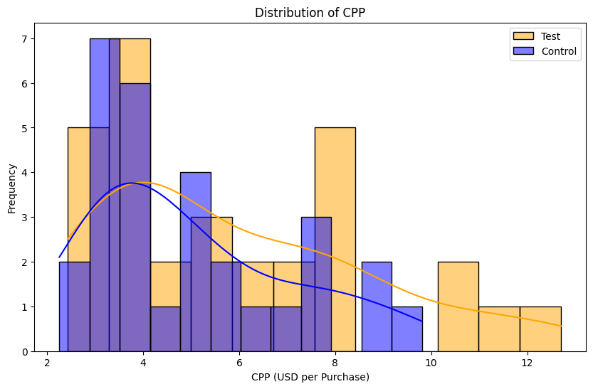

```python
# Visualize distributions
plt.figure(figsize=(10, 6))
sns.histplot(test_df['CPP'], kde=True, label='Test', color='orange', bins=12)
sns.histplot(control_df['CPP'], kde=True, label='Control', color='blue', bins=12, alpha=0.5)
plt.title('Distribution of CPP')
plt.xlabel('CPP (USD per Purchase)')
plt.ylabel('Frequency')
plt.legend()
plt.show()
```

```python
# Check Distribution of CPP using
# Shapiro-Wilk Test for Normality
_, p_control = shapiro(control_df['CPP'])
_, p_test = shapiro(test_df['CPP'])

print(f"Shapiro-Wilk p-value (Control): {p_control}")
print(f"Shapiro-Wilk p-value (Test): {p_test}")
```

```
Shapiro-Wilk p-value (Control): 0.011892481707036495
Shapiro-Wilk p-value (Test): 0.006934247445315123
```

Since the **Shapiro-Wilk p-values** for both the Control and Test groups are **less than 0.05**, we can conclude that the **CPA (Cost Per Acquisition)** data for both groups is **not normally distributed**. This means we should use a **non-parametric test** (e.g., **Mann-Whitney U Test**) instead of a parametric test like the **T-Test**.

```
Mann-Whitney U Statistic: 369.0
P-value: 0.2339889162810581
Fail to reject the null hypothesis: There is no statistically significant difference in CPA between the two groups.
```

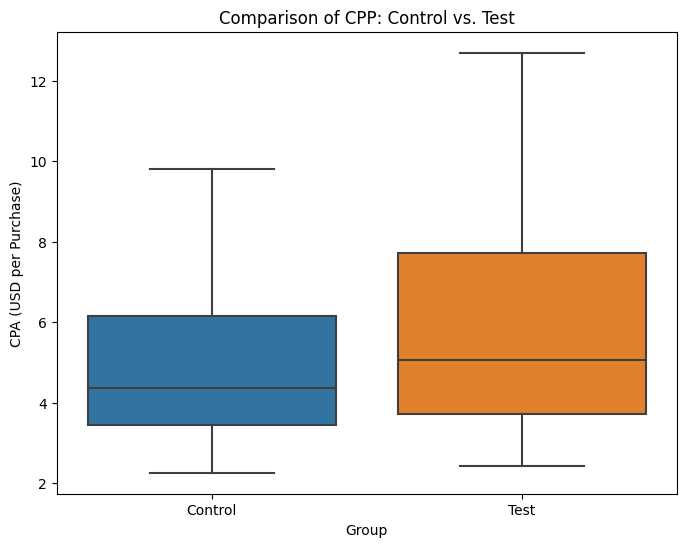

```python
# Perform the test
stat, p_value = mannwhitneyu(control_df['CPP'].dropna(), test_df['CPP'].dropna(), alternative='two-sided')

print(f"Mann-Whitney U Statistic: {stat}")
print(f"P-value: {p_value}")

# Interpret the results
if p_value < 0.05:
    print("Reject the null hypothesis: There is a statistically significant difference in CPA between the two groups.")
else:
    print("Fail to reject the null hypothesis: There is no statistically significant difference in CPA between the two groups.")

# Step 2: Visualize CPA Comparison
plt.figure(figsize=(8, 6))
sns.boxplot(x='Group', y='CPP', data=pd.concat([
    control_df.assign(Group='Control'),
    test_df.assign(Group='Test')
]))
plt.title('Comparison of CPP: Control vs. Test')
plt.ylabel('CPA (USD per Purchase)')
plt.show()
```

### **Explanation of Results**

1. **Mann-Whitney U Test**:
   - The **Mann-Whitney U Test** is a non-parametric test used to compare two independent groups when the data is not normally distributed.
   - **Null Hypothesis (H₀)**: The distributions of the two groups are equal.
   - **Alternative Hypothesis (H₁)**: The distributions of the two groups are not equal.
2. **Interpretation**:
   - If the **p-value** is less than **0.05**, we reject the null hypothesis and conclude that there is a statistically significant difference in CPA between the Control and Test groups.
   - If the **p-value** is greater than **0.05**, we fail to reject the null hypothesis and conclude that there is no statistically significant difference in CPA between the two groups.

The results of the **Mann-Whitney U Test** indicate that the **p-value is 0.234**, which is **greater than 0.05**. This means we **fail to reject the null hypothesis**, and we conclude that there is **no statistically significant difference in CPA (Cost Per Acquisition)** between the Control and Test groups.

### **Interpretation of Results**

1. **No Significant Difference**:
   - The CPA for the Control and Test groups is not significantly different.
   - This suggests that both campaigns performed similarly in terms of cost efficiency for generating purchases.
2. **Implications**:
   - If the goal was to determine which campaign is more cost-effective, the results indicate that neither campaign outperformed the other significantly.
   - You may need to explore other metrics (e.g., conversion rate, ROI) or run the experiment for a longer duration to detect smaller differences.

### **Explore Other Metrics**

Analyze other key performance indicators (KPIs) such as:

- **Conversion Rate**: $ \begin{align} \text{Conversion Rate} = \frac{\text{Number of Purchases}}{\text{Number of Website Clicks}} \end{align} $
- **Click-Through Rate (CTR)**: $ \begin{align} \text{CTR} = \frac{\text{Number of Clicks}}{\text{Number of Impressions}} \end{align} $
- **Return on Investment (ROI)**: $ \begin{align} \text{ROI} = \frac{\text{Revenue - Campaign Spend}}{\text{Campaign Spend}} \end{align} $
- **Customer Lifetime Value (CLV)**: $ \begin{align} \text{CLV} = \text{Average Purchase Value} \times \text{Purchase Frequency} \times \text{Customer Lifespan} \end{align} $

There is currentry data only for CR and CTR

## **CR and CTR**

```python
# Calculate CR and CTR for each day
control_df['CR'] = control_df['Purchases']/ control_df['Clicks']
test_df['CR'] = test_df['Purchases']/ test_df['Clicks']

control_df['CTR'] = control_df['Clicks'] / control_df['Impressions']
test_df['CTR'] = test_df['Clicks'] / test_df['Impressions']
```

### **CR and CTR: Hypothesis Formulation**

#### **For Conversion Rate (CR)**:

- **Null Hypothesis (H₀)**:
  - The **population mean Conversion Rate (CR)** of the Control group is equal to the population mean Conversion Rate of the Test group.
- **Alternative Hypothesis (H₁)**:
  - The **population mean Conversion Rate (CR)** of the Control group is not equal to the population mean Conversion Rate of the Test group.

#### **For Click-Through Rate (CTR)**:

- **Null Hypothesis (H₀)**:
  - The **population mean Click-Through Rate (CTR)** of the Control group is equal to the population mean Click-Through Rate of the Test group.
- **Alternative Hypothesis (H₁)**:
  - The **population mean Click-Through Rate (CTR)** of the Control group is not equal to the population mean Click-Through Rate of the Test group.

```python
# Shapiro-Wilk Test for Normality
_, p_cr_control = shapiro(control_df['CR'])
_, p_cr_test = shapiro(test_df['CR'])
_, p_ctr_control = shapiro(control_df['CTR'])
_, p_ctr_test = shapiro(test_df['CTR'])

print(f"Shapiro-Wilk p-value (CR Control): {p_cr_control}")
print(f"Shapiro-Wilk p-value (CR Test): {p_cr_test}")
print(f"Shapiro-Wilk p-value (CTR Control): {p_ctr_control}")
print(f"Shapiro-Wilk p-value (CTR Test): {p_ctr_test}")
```

```
Shapiro-Wilk p-value (CR Control): 0.005544630810618401
Shapiro-Wilk p-value (CR Test): 0.037268370389938354
Shapiro-Wilk p-value (CTR Control): 0.25710153579711914
Shapiro-Wilk p-value (CTR Test): 0.00040253173210658133
```

```python
combined_df=pd.concat([
    control_df.assign(Group='Control Campaign'),
    test_df.assign(Group='Test Campaign')
])
# Reset the index of combined_df to avoid duplicate labels
combined_df = combined_df.reset_index(drop=True)
```

### **Interpretation of Shapiro-Wilk p-values**

1. **CR Control**:
   - **p-value = 0.0055**
   - Since the p-value is **less than 0.05**, we **reject the null hypothesis** of the Shapiro-Wilk test.
   - **Conclusion**: The CR data for the Control group is **not normally distributed**.
2. **CR Test**:
   - **p-value = 0.0373**
   - Since the p-value is **less than 0.05**, we **reject the null hypothesis** of the Shapiro-Wilk test.
   - **Conclusion**: The CR data for the Test group is **not normally distributed**.
3. **CTR Control**:
   - **p-value = 0.2571**
   - Since the p-value is **greater than 0.05**, we **fail to reject the null hypothesis** of the Shapiro-Wilk test.
   - **Conclusion**: The CTR data for the Control group is **normally distributed**.
4. **CTR Test**:
   - **p-value = 0.0004**
   - Since the p-value is **less than 0.05**, we **reject the null hypothesis** of the Shapiro-Wilk test.
   - **Conclusion**: The CTR data for the Test group is **not normally distributed**.

### **Implications for Statistical Testing**

1. **Conversion Rate (CR)**:
   - Both the Control and Test groups have **non-normally distributed CR data**.
   - **Recommended Test**: Use a **non-parametric test** like the **Mann-Whitney U Test** to compare the CR between the two groups.
2. **Click-Through Rate (CTR)**:
   - The Control group has **normally distributed CTR data**, but the Test group has **non-normally distributed CTR data**.
   - **Recommended Test**: Use a **non-parametric test** like the **Mann-Whitney U Test** to compare the CTR between the two groups, as the assumptions for parametric tests (e.g., T-Test) are not fully met.

```
Mann-Whitney U Statistic (CR): 523.0
P-value (CR): 0.2837780479456242
Mann-Whitney U Statistic (CTR): 197.0
P-value (CTR): 0.00018916193602108462
```

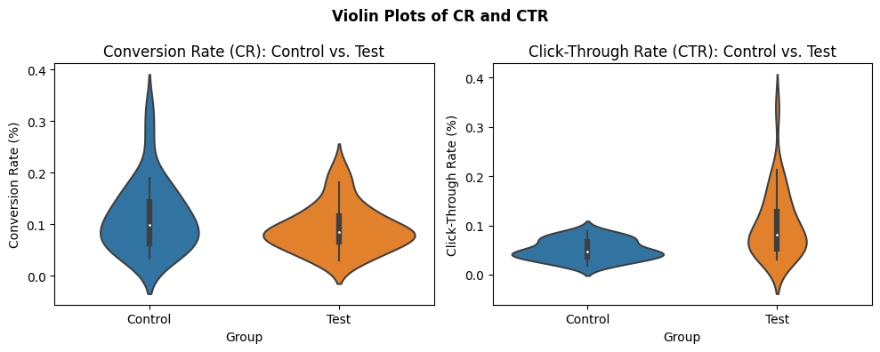

```python
# Perform Mann-Whitney U Test for CR
stat_cr, p_value_cr = mannwhitneyu(control_df['CR'], test_df['CR'], alternative='two-sided')
print(f"Mann-Whitney U Statistic (CR): {stat_cr}")
print(f"P-value (CR): {p_value_cr}")

# Perform Mann-Whitney U Test for CTR
stat_ctr, p_value_ctr = mannwhitneyu(control_df['CTR'], test_df['CTR'], alternative='two-sided')
print(f"Mann-Whitney U Statistic (CTR): {stat_ctr}")
print(f"P-value (CTR): {p_value_ctr}")


# Create subplots
fig, (ax1, ax2) = plt.subplots(ncols=2, figsize=(10, 4))
fig.suptitle('Violin Plots of CR and CTR',fontweight='bold')

# Violin plot for CR
sns.violinplot(x='Group', y='CR', data=pd.concat([
    control_df.assign(Group='Control'),
    test_df.assign(Group='Test')
]), ax=ax1)
ax1.set_title('Conversion Rate (CR): Control vs. Test')
ax1.set_ylabel('Conversion Rate (%)')

# Violin plot for CTR
sns.violinplot(x='Group', y='CTR', data=pd.concat([
    control_df.assign(Group='Control'),
    test_df.assign(Group='Test')
]), ax=ax2)
ax2.set_title('Click-Through Rate (CTR): Control vs. Test')
ax2.set_ylabel('Click-Through Rate (%)')

# Adjust layout
plt.tight_layout()
plt.show()
```

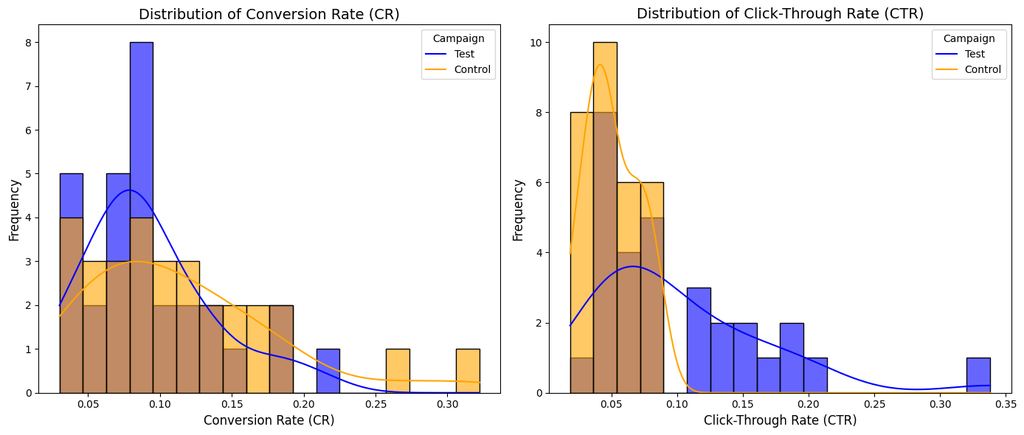

```python
plt.figure(figsize=(14, 6))

# Subplot 1: Distribution of CR
plt.subplot(1, 2, 1)
sns.histplot(data=combined_df, x='CR', hue='Group', kde=True, palette=['orange','blue'], bins=18, alpha=0.6)
plt.title('Distribution of Conversion Rate (CR)', fontsize=14)
plt.xlabel('Conversion Rate (CR)', fontsize=12)
plt.ylabel('Frequency', fontsize=12)
plt.legend(title='Campaign', fontsize=10, labels=['Test','Control'])

# Subplot 2: Distribution of CTR
plt.subplot(1, 2, 2)
sns.histplot(data=combined_df, x='CTR', hue='Group', kde=True, palette=['orange','blue'], bins=18, alpha=0.6)
plt.title('Distribution of Click-Through Rate (CTR)', fontsize=14)
plt.xlabel('Click-Through Rate (CTR)', fontsize=12)
plt.ylabel('Frequency', fontsize=12)
plt.legend(title='Campaign', fontsize=10,labels=['Test','Control'])

# Adjust layout
plt.tight_layout()
plt.show()
```

| **Conversion Rate (CR)** | **Click-Through Rate (CTR)** |
| --- | --- |
| **Results**: | **Results**: |
| - **Mann-Whitney U Statistic (CR)**: 523.0 | - **Mann-Whitney U Statistic (CTR)**: 197.0 |
| - **P-value (CR)**: 0.2838 | - **P-value (CTR)**: 0.00019 |
| **Interpretation**: | **Interpretation**: |
| - The **p-value (0.2838)** is **greater than 0.05**. | - The **p-value (0.00019)** is **less than 0.05**. |
| - This means we **fail to reject the null hypothesis**. | - This means we **reject the null hypothesis**. |
| **Conclusion**: | **Conclusion**: |
| - There is **no statistically significant difference** in the **Conversion Rate (CR)** between the Control and Test groups. | - There is a **statistically significant difference** in the **Click-Through Rate (CTR)** between the Control and Test groups. |

### **Key Insights**

1. **Conversion Rate (CR)**:
   - The lack of a statistically significant difference suggests that the two campaigns performed similarly in terms of converting users who clicked on the ad into purchasers.
   - This could mean that the changes made in the Test campaign did not have a meaningful impact on the conversion rate.
2. **Click-Through Rate (CTR)**:
   - The statistically significant difference in CTR suggests that the Test campaign performed differently from the Control campaign in terms of attracting clicks.
   - To determine which campaign performed better, you can compare the **median CTR** or **mean CTR** of the two groups:
     - If the Test campaign has a higher median/mean CTR, it performed better.
     - If the Control campaign has a higher median/mean CTR, it performed better.

### **Next Steps**

1. **For CTR**:
   - Investigate why the Test campaign had a significantly different CTR. For example:
     - Was the ad copy or design more engaging in the Test campaign?
     - Were there differences in targeting or ad placement?
   - If the Test campaign had a higher CTR, consider scaling it up. If it had a lower CTR, analyze what went wrong and refine the strategy.
2. **For CR**:
   - Since there was no significant difference in CR, focus on other aspects of the campaign (e.g., ad spend efficiency, ROI) to determine which campaign is more effective overall.
3. **Further Analysis**:
   - Perform additional statistical tests or exploratory data analysis (EDA) to understand other factors that might have influenced the results.
   - Consider running the experiment for a longer duration to see if the results hold over time.